# Client Report -How good is it, really?

- Show All Code
- Hide All Code

Unit 4 Task 2

Author

Jayden Pope

```python
import polars as pl
import numpy as np
from lets_plot import *
from sklearn.model_selection import train_test_split
from sklearn import metrics
from sklearn.ensemble import RandomForestClassifier
from sklearn.metrics import accuracy_score
import matplotlib.pyplot as plt
from sklearn.inspection import permutation_importance
from sklearn.metrics import confusion_matrix
from sklearn.metrics import classification_report
from sklearn.metrics import ConfusionMatrixDisplay
# add the additional libraries you need to import for ML here

LetsPlot.setup_html(isolated_frame=True)
```

```python
# import your data here using polars and the URL
url = "https://github.com/byuidatascience/data4dwellings/raw/master/data-raw/dwellings_ml/dwellings_ml.csv"

data = pl.read_csv(url)
data

y = (data["yrbuilt"] < 1980).to_numpy()
X = data.drop("yrbuilt", "before1980", "parcel", strict=False)

X_train, X_test, y_train, y_test = train_test_split(
    X, y, test_size=0.2, stratify=y, random_state=42
)

model = RandomForestClassifier(n_estimators=400, random_state=42, n_jobs=-1)
model.fit(X_train, y_train)
```

```
RandomForestClassifier(n_estimators=400, n_jobs=-1, random_state=42)
```

## QUESTION 1

1. **Describe the quality of your classification model using 2-3 different evaluation metrics.** You also need to explain how to define/interpret each of the evaluation metrics you use.

To evaluate the quality of my model I measured the total accuracy score of the model with the test partition, created a Confusion Matrix to display the number of houses in each category, and the model’s accuracy with it’s sorting, and final made a classification report in order to assess how the model performed in sorting into either category and how even the data pools training happened with.

First off the simplest metric is the accuracy score. The model had an accuracy of 92%-93% with it’s choices.

Finally the classification report is the most detailed analysis of the model showing that when a house was built in 1980 or later the model correctly labled it as such 90% of the time and of the data given it correctly labeled them 91% of the time for an f1-score of 91 the measures of such being built upon 1719 houses worth of data. On the other end the model labeled a house as from before 1980 94% of the time and of the data given to it correctly labled them also 94% of the time for a f1-score of 94% this training set consisting of 2864 instances of houses built before 1980. While the representation for houses from each group is weighted towards houses built before 1980 by a decent margin, the consistent accuracy for both categories leaves me confident in it’s results.

I’m especially confident because there’s only a 1% difference in the precision, recall, and f1-scores between the macro avg where both houses built before and during/after 1980 are given equal importance and the weighted avg where importance mirrors the difference in support present between the 2 catagories.

What my Feature importances graph does show is that I confused what the model found most important with what actually are the most important distinguishing factors for sorting between houses built before 1980 and during/after 1980.

```
forest 0.928649356316823
```

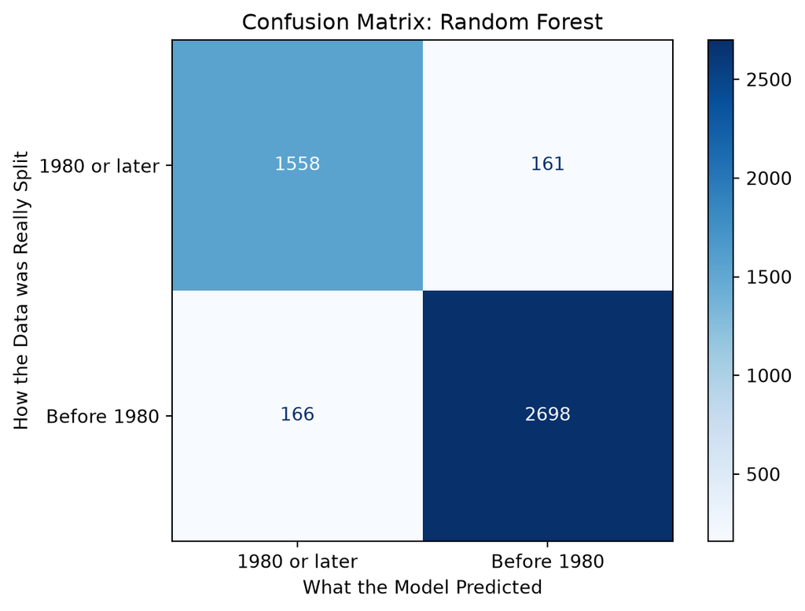

```
              precision    recall  f1-score   support

       False       0.90      0.91      0.91      1719
        True       0.94      0.94      0.94      2864

    accuracy                           0.93      4583
   macro avg       0.92      0.92      0.92      4583
weighted avg       0.93      0.93      0.93      4583
```

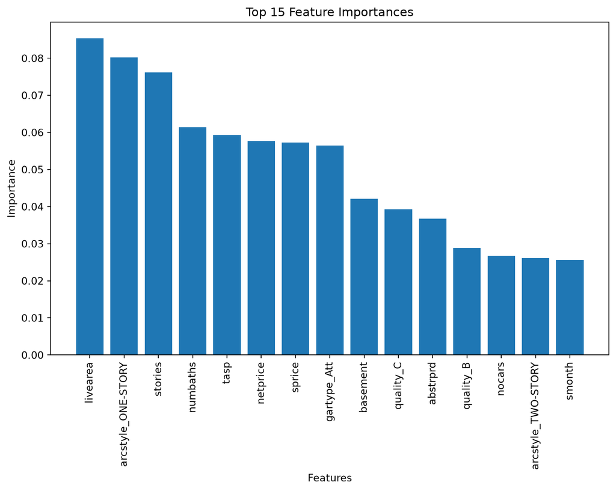

```python
y_pred = model.predict(X_test)

print("forest", accuracy_score(y_test, y_pred))

ConfusionMatrixDisplay.from_predictions(
    y_test, y_pred,
    display_labels=["1980 or later", "Before 1980"],
    cmap="Blues",
)
plt.title("Confusion Matrix: Random Forest")
plt.xlabel("What the Model Predicted")
plt.ylabel("How the Data was Really Split")
plt.show()

print(classification_report(y_test, y_pred))

importances = model.feature_importances_
indices = np.argsort(importances)[::-1]


names = [X.columns[i] for i in indices]

plt.figure(figsize=(10, 6))
plt.title("Top 15 Feature Importances")
plt.bar(range(15), importances[indices][:15])
plt.xticks(range(15), names[:15], rotation=90)
plt.xlabel("Features")
plt.ylabel("Importance")
plt.show()
```

## QUESTION 2

1. **Justify your classification model by discussing the most important features selected by your model.** This discussion should include a plot of permutation importance values for the most important features. Were there any features you thought would be importance but weren’t?

All the factors I predicted would be important are within the top 15 most important features. Normally I wouldn’t say this is accurate enough but it’s important to consider how much variance each permutation would result in when removed.

Even the most important featuring being the gartype_Att when removed only resulted in a 4% decrease in accuracy. This mean that like I predicted in task 1, no individual feature is truly distinct enough for anyone to confidently say a house was built before 1980 and as a matter of fact it requires a variety of features to correctly identify if a house was built before 1980 or during/after 1980.

Also features like tasp are linked to other financial features and their importance is reduced by the existence of other features that provide similar, or the same data.

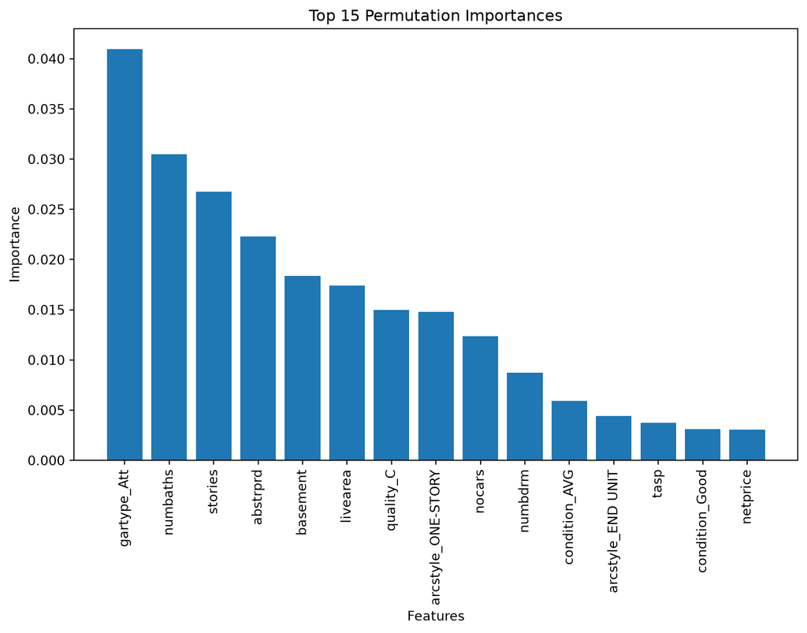

```python
result = permutation_importance(
    model, X_test, y_test, n_repeats=10, random_state=42, n_jobs=1
)

importances = result.importances_mean
indices = np.argsort(importances)[::-1]


names = [X.columns[i] for i in indices]

plt.figure(figsize=(10, 6))
plt.title("Top 15 Permutation Importances")
plt.bar(range(15), importances[indices][:15])
plt.xticks(range(15), names[:15], rotation=90)
plt.xlabel("Features")
plt.ylabel("Importance")
plt.show()
```

## QUESTION 3

1. **For the 3 most important features, explain their relationship to the target variable. Use a plot to illustrate the relationship.** (3 plots minimum)

Attached Garages: We can see that in both the trimmed and untrimmed data that just under 80% of houses without an attached garage are from before 1980 and around 40% of houses with 1 attached garage are from before 1980

Number of Bathrooms: In the trimmed data the number bathrooms ranges from 1-7, the most common being 1 at around 85% of houses with a single bathroom being built before 1980. Wheras in the untrimmed data we can see the reason I decide to trim data in the first place, the number of bathrooms ranges from 0-11 with percentages of 100% of houses with 0, 9, and 11 bathrooms being built before 1980, this is almost definitely because just 1 house with these numbers of bathrooms were within the provided data creating a misleading skew.

Number of Stories: The trimmed and untrimmed data showcase that on average 80% of homes that are 1 story tall were built before 1980 but houses ranging from 1-4 stories are all possible.

```python
def plot_pct_old_cut(col, title):
    summary = (
        data
        .with_columns(before1980=pl.col("yrbuilt") < 1980)
        .group_by(col)
        .agg(
            pct_old=pl.col("before1980").mean() * 100,
            homes=pl.len(),
        )
        .filter(pl.col("homes") >= 30)
        .sort(col)
    )

    plt.figure(figsize=(8, 5))
    plt.bar(summary[col].cast(pl.String), summary["pct_old"])
    plt.title(title)
    plt.xlabel(col)
    plt.ylabel("% of homes built before 1980")
    plt.ylim(0, 100)
    plt.show()

    return summary

def plot_pct_old_all(col, title):
    summary = (
        data
        .with_columns(before1980=pl.col("yrbuilt") < 1980)
        .group_by(col)
        .agg(
            pct_old=pl.col("before1980").mean() * 100,
            homes=pl.len(),
        )
        .sort(col)
    )

    plt.figure(figsize=(8, 5))
    plt.bar(summary[col].cast(pl.String), summary["pct_old"])
    plt.title(title)
    plt.xlabel(col)
    plt.ylabel("% of homes built before 1980")
    plt.ylim(0, 100)
    plt.show()

    return summary
```

## Trimmed Data vs Untrimmed Data

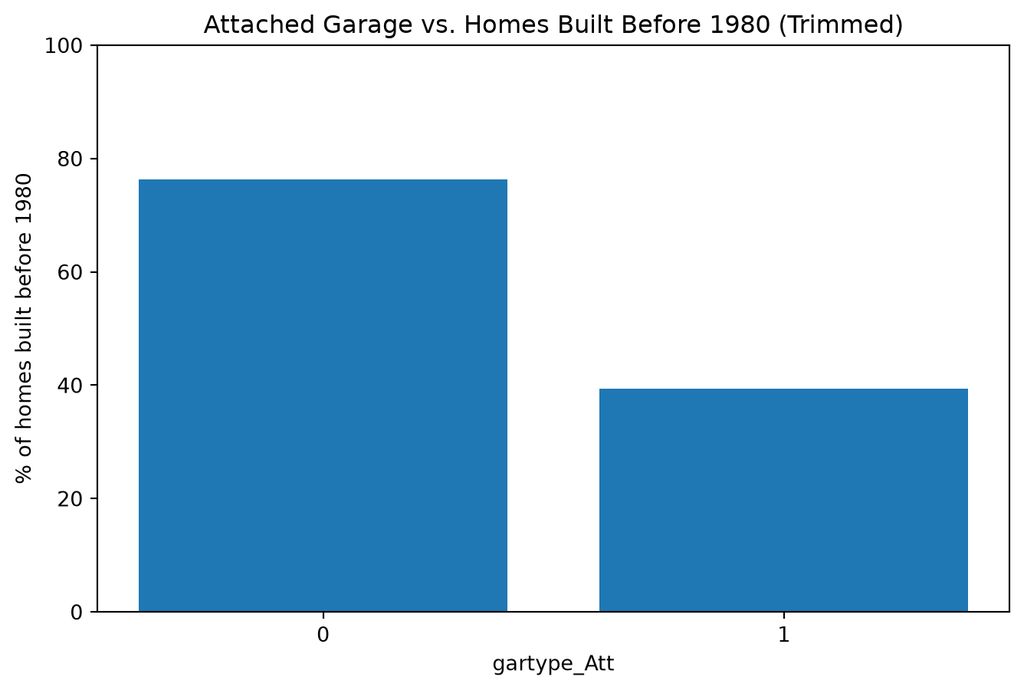

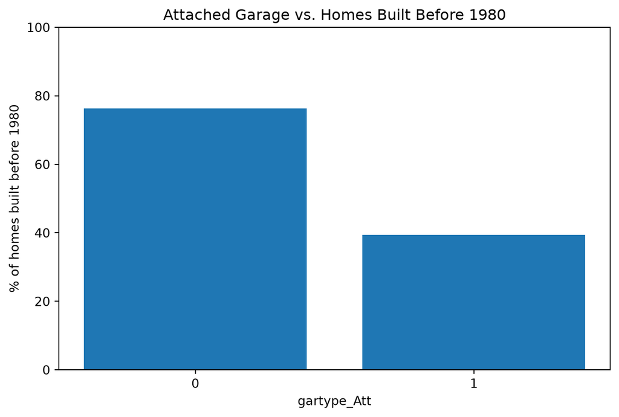

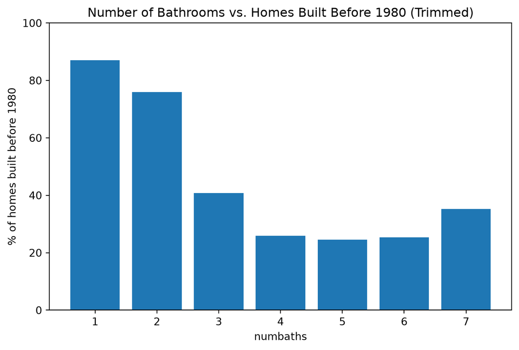

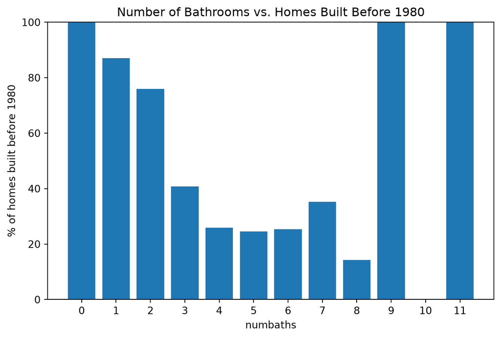

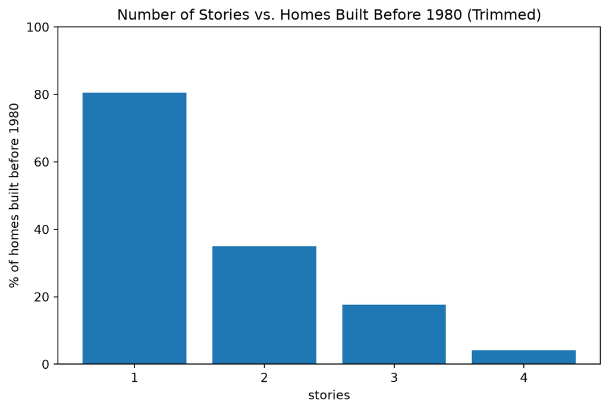

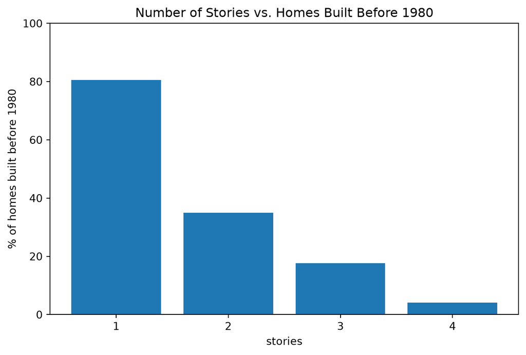

```python
plot_pct_old_cut("gartype_Att", "Attached Garage vs. Homes Built Before 1980 (Trimmed)")
plot_pct_old_all("gartype_Att", "Attached Garage vs. Homes Built Before 1980")

plot_pct_old_cut("numbaths", "Number of Bathrooms vs. Homes Built Before 1980 (Trimmed)")
plot_pct_old_all("numbaths", "Number of Bathrooms vs. Homes Built Before 1980")

plot_pct_old_cut("stories", "Number of Stories vs. Homes Built Before 1980 (Trimmed)")
plot_pct_old_all("stories", "Number of Stories vs. Homes Built Before 1980");
```